# catch data

Mathias Msafiri Igulu

1/15/2020

yoU can learn the usage of tidyverse package in detail in a book R for data science written by Hadley Wickham. You can access an online book, which is free at this [link](https://r4ds.had.co.nz/data-import.html)

We need to load the packages that contains function required for this processes. Use the `require()` function to load the packages in the session

```r
require(tidyverse)
require(astsa)
require(ggpmisc)
require(ggfortify)
require(forecast)
```

Our data is stored in Excel spreadsheet, and tidyverse packages lack the function to import or export excel file. However, there **readxl** package that contains tools to read and export files in Excell format.

```r
catch = readxl::read_excel(path = "data_revised.xlsx",sheet = 1, col_names = TRUE )
```

we noticed that column 6 and 7 have been renamed, but we know these columns data were removed from the files. therefore, we also need to trim them off from the dataset.

```r
catch.clean = catch %>%
  select(Location, Year, Month, Species,catch = 5)
```

trend in fish catch Clean months with typos to correct Month names

```r
# catch.clean %>% group_by(Month) %>% tally()

catch.clean = catch.clean %>%
  mutate(Month = replace(Month, Month == "Augast", "August"),
         Month = replace(Month, Month == "december", "December"),
         Month = replace(Month, Month == "september", "September"),
         Year = as.integer(Year)) %>%
  mutate(day = 15,
         Month = replace(Month, Month == "January", 1),
         Month = replace(Month, Month == "February", 2),
         Month = replace(Month, Month == "March", 3),
         Month = replace(Month, Month == "April", 4),
         Month = replace(Month, Month == "May", 5),
         Month = replace(Month, Month == "June", 6),
         Month = replace(Month, Month == "July", 7),
         Month = replace(Month, Month == "August", 8),
         Month = replace(Month, Month == "September", 9),
         Month = replace(Month, Month == "October", 10),
         Month = replace(Month, Month == "November", 11),
         Month = replace(Month, Month == "December", 12),
         Month = as.integer(Month),
         date = lubridate::make_date(year = Year, month = Month, day = day),
         catch =   catch %>% oce::despike())
```

Clean species but seems ok

```r
kigamboni = catch.clean %>%
  group_by(Species, Location) %>%
  tally() %>%
  arrange(desc(n)) %>% ungroup() %>%
  filter(Location == "Kigamboni") %>%
  separate(col = Species, into = c("Species", "others"), sep = " " )%>%
  mutate(percentage = (n/sum(n) * 100) %>% round(2), cumsum = cumsum(percentage),
         labs = paste(percentage,"%", Species)) %>%
  filter(cumsum <= 50)
```

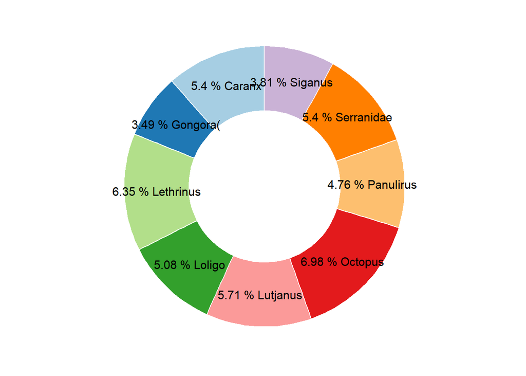

```r
  kigamboni %>%
    ggpubr::ggdonutchart(x = "n",
                       label = "labs",
                       fill = "Species", color = "white", lab.pos = "in")+
  # scale_fill_viridis_d() +
    scale_fill_brewer(palette = "Paired")+
  theme(legend.position = "none")
```

```r
library(ggpubr)
# Data: Create some data
# +++++++++++++++++++++++++++++++

df <- data.frame(
 group = c("Male", "Female", "Child"),
  value = c(25, 25, 50))

head(df)
```

```
##    group value
## 1   Male    25
## 2 Female    25
## 3  Child    50
```

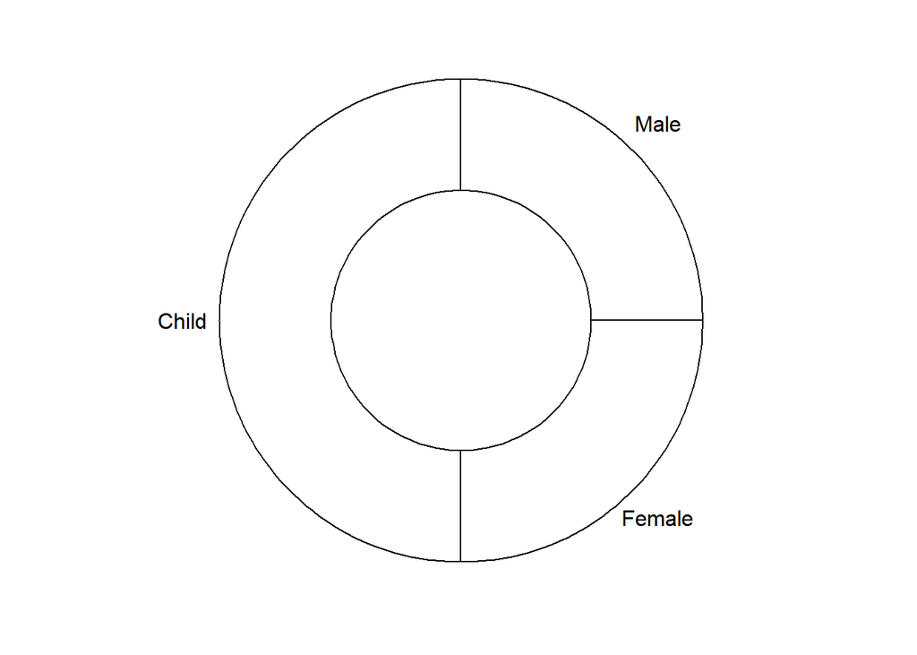

```r
# Basic pie charts
# ++++++++++++++++++++++++++++++++

ggdonutchart(df, "value", label = "group")
```

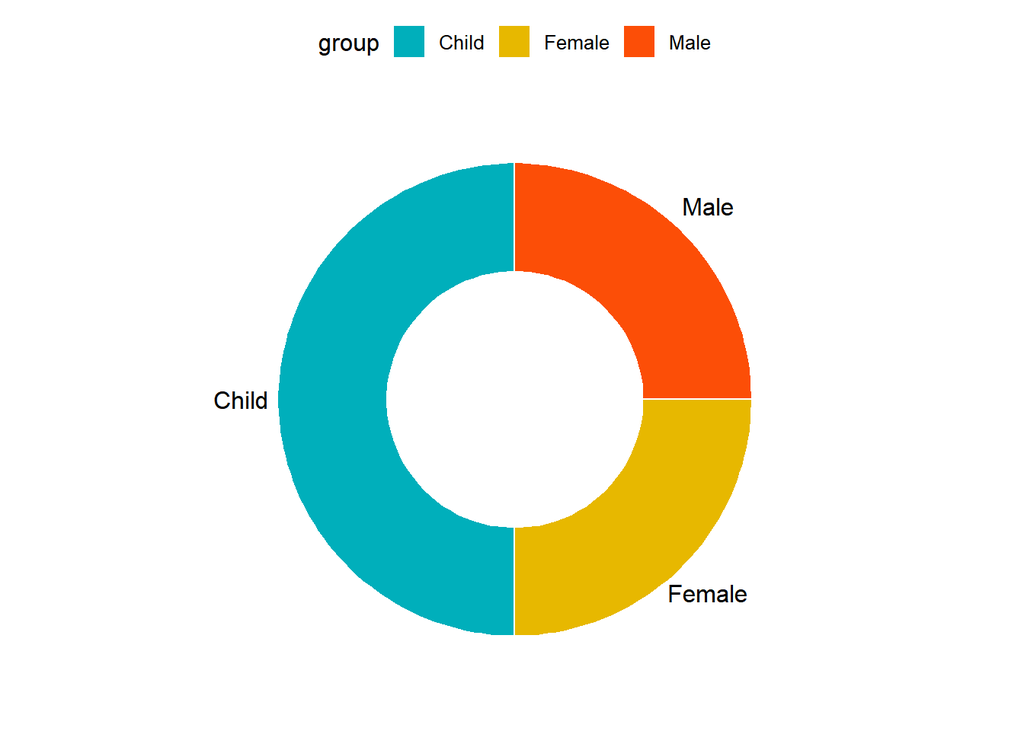

```r
# Change color
# ++++++++++++++++++++++++++++++++

# Change fill color by group
# set line color to white
# Use custom color palette
 ggdonutchart(df, "value", label = "group",
      fill = "group", color = "white",
       palette = c("#00AFBB", "#E7B800", "#FC4E07") )
```

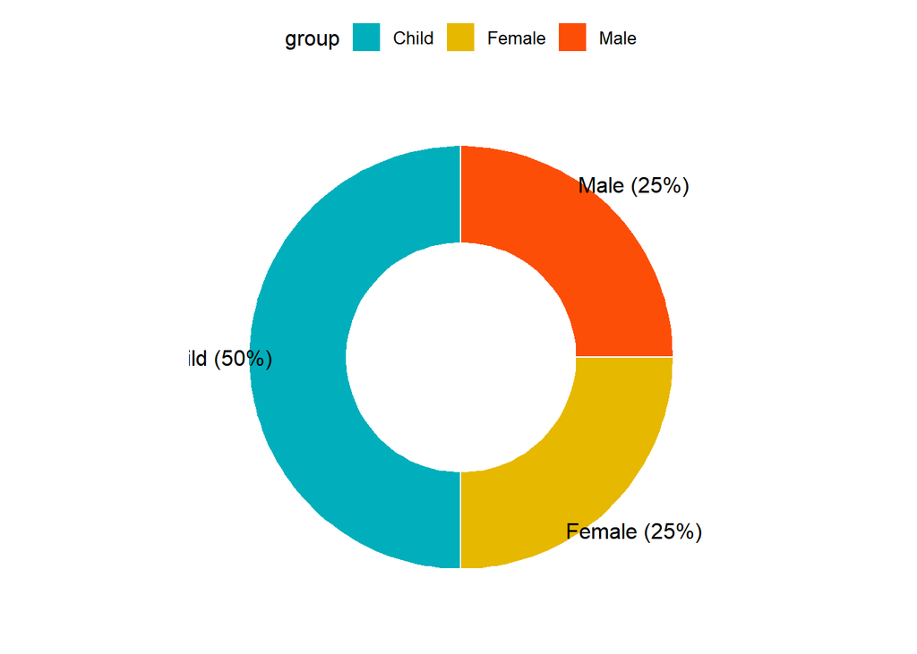

```r
# Change label
# ++++++++++++++++++++++++++++++++

# Show group names and value as labels
labs <- paste0(df$group, " (", df$value, "%)")
ggdonutchart(df, "value", label = labs,
   fill = "group", color = "white",
   palette = c("#00AFBB", "#E7B800", "#FC4E07"))
```

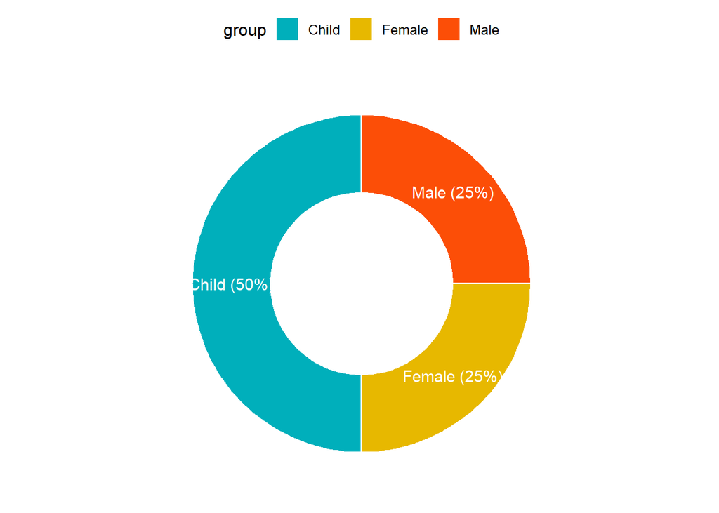

```r
# Change the position and font color of labels
ggdonutchart(df, "value", label = labs,
   lab.pos = "in", lab.font = "white",
   fill = "group", color = "white",
   palette = c("#00AFBB", "#E7B800", "#FC4E07"))
```

```r
catch.clean.group = catch.clean %>%
  group_by(Location, date) %>%
  summarise(catch = median(catch, na.rm = TRUE)) %>%
  ungroup()
```

## Fish catch trends

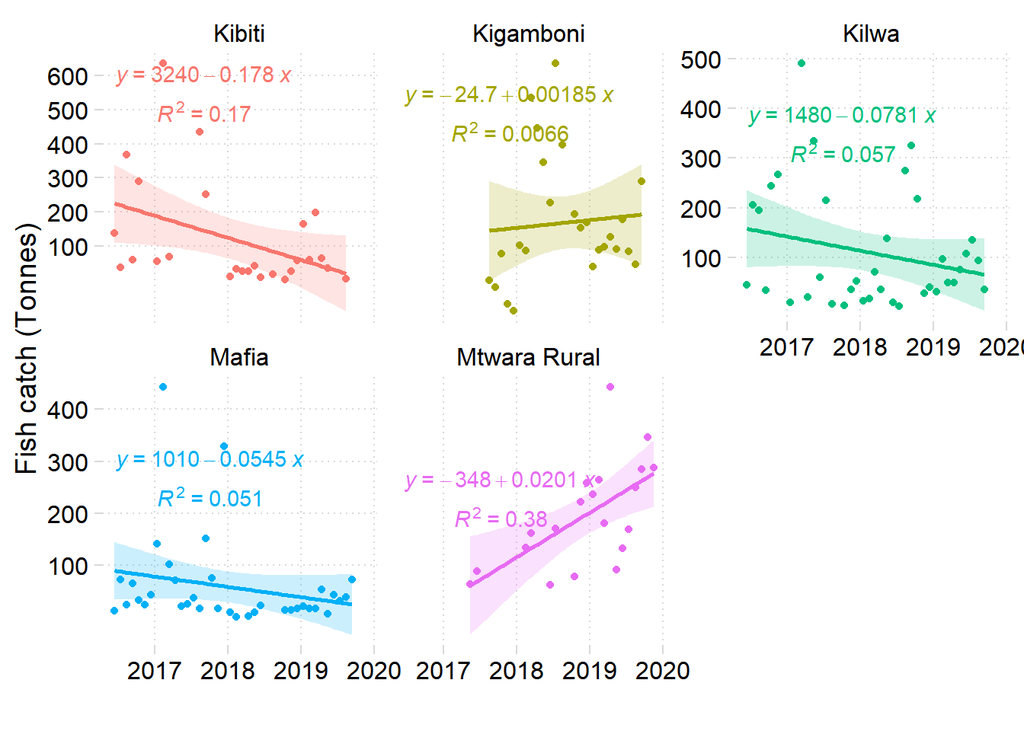

```r
catch.clean.group = catch.clean.group %>%
  arrange(date)

 now= catch.clean.group %>% filter(catch > 250 & catch < 420) %>%
   mutate(mwezi = lubridate::month(date, abbr = TRUE, label = TRUE),
          year = lubridate::year(date) %>% as.integer(),
          label = paste(mwezi, ", ",year))

formula1 <- y ~ x

ggplot(data = catch.clean.group ,
       aes(x = date, y = catch, col = Location, fill = Location))+
  geom_point()+
  geom_smooth(se = TRUE, alpha = .2, method = "lm", formula = formula1)+
  # stat_fit_tb(method = "lm",
  #             method.args = list(formula = formula1),
  #             tb.vars = c(Parameter = "term",
  #                         Estimate = "estimate",
  #                         "s.e." = "std.error",
  #                         "italic(t)" = "statistic",
  #                         "italic(P)" = "p.value"),
  #             label.y = "top", label.x = "right",
  #             parse = TRUE)+
  stat_poly_eq(aes(label = paste0("atop(", ..eq.label.., ",", ..rr.label.., ")")),
               formula = formula1, rr.digits = 2,
               parse = TRUE) +
  # ggrepel::geom_text_repel(data = now, aes(x = date, y = catch, label = label)) +
  scale_x_date(date_minor_breaks = "1 month") +
  scale_y_continuous(breaks = seq(100,600,100))+
  cowplot::theme_minimal_grid()+
  theme(panel.grid = element_line(linetype = "dotted"), legend.position = "none")+
  facet_wrap(~Location, scales = "free_y")+
  labs(x = "", y = "Fish catch (Tonnes)")
```

```r
# ggsave("fig1.pdf")
```

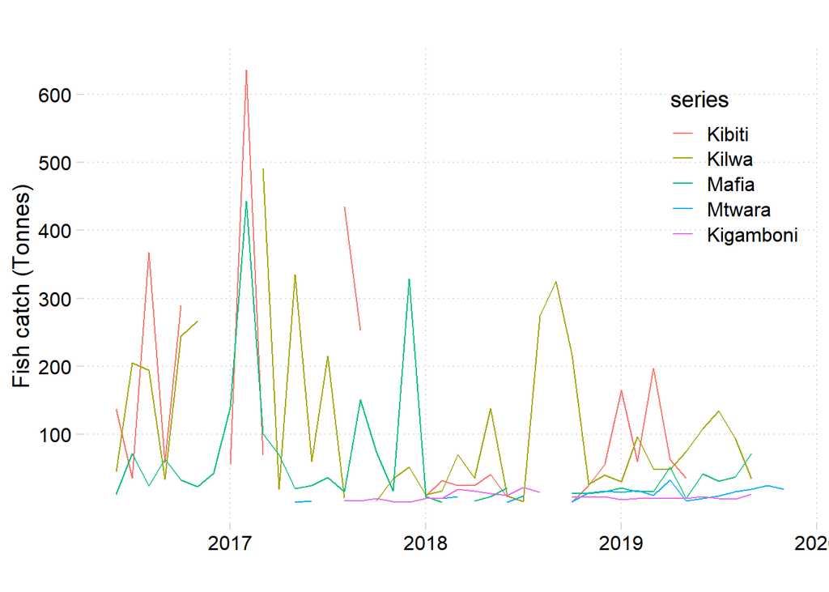

```r
catch.clean.group.wide = catch.clean.group %>% ungroup() %>% select(date, Location, catch) %>% pivot_wider(names_from = "Location", values_from = "catch") %>% arrange(date)


ts.series = ts.intersect(
  Kibiti = ts(data = catch.clean.group.wide %>% pull(Kibiti),start = c(2016,6), frequency = 12),
  Kilwa = ts(data = catch.clean.group.wide %>% pull(Kilwa),start = c(2016,6), frequency = 12),
  Mafia = ts(data = catch.clean.group.wide %>% pull(Mafia),start = c(2016,6), frequency = 12),
  Mtwara = ts(data = catch.clean.group.wide %>% pull(`Mtwara Rural`),start = c(2016,6), frequency = 12),
  Kigamboni = ts(data = catch.clean.group.wide %>% pull(Kigamboni),start = c(2016,6), frequency = 12)
  )

ts.series %>%
  autoplot() +
  cowplot::theme_minimal_grid()+
  theme(panel.grid = element_line(linetype = "dotted"), legend.position = c(.80,.75))+
  scale_y_continuous(breaks = seq(100,600,100))+
  labs(x = "", y = "Fish catch (Tonnes)")
```

```r
# ggsave("fig2.pdf")
```

We notice that only the catch data has few missing values. Then we use it to represent the trend of cath. Because the data ends in september 2019, we extended for two more years and forecast the catches of fish in this site until september 2021. We add six months moving average on the plot

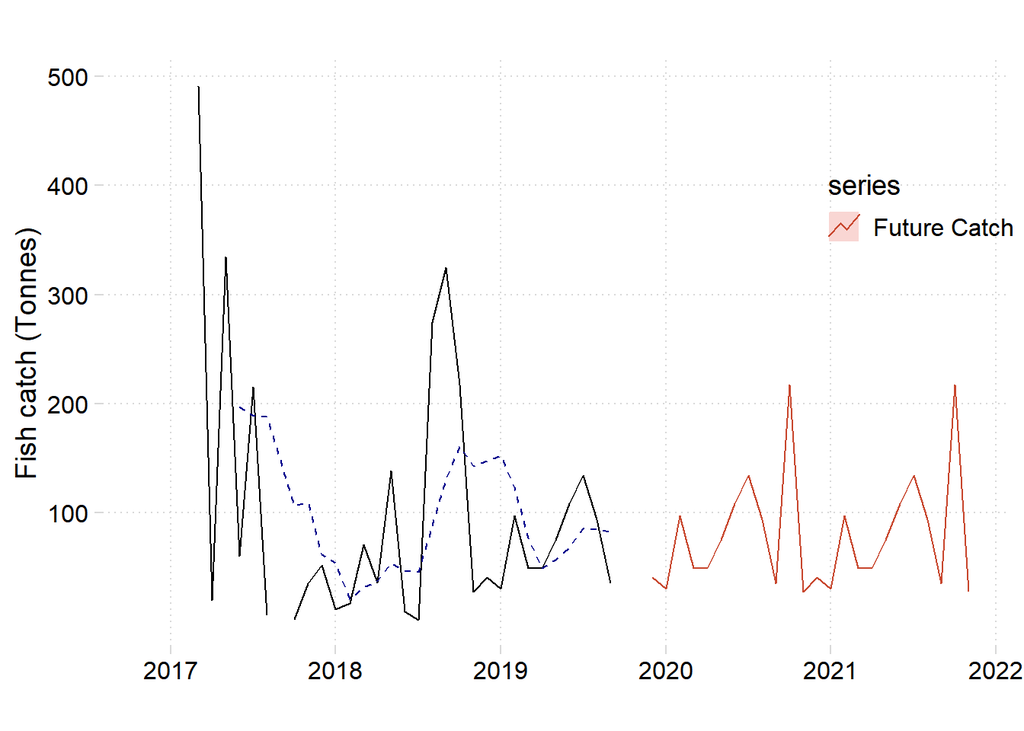

```r
ts.series[,2] %>%
  window(start = c(2016,11)) %>%
  autoplot() +
  autolayer(snaive(y = ts.series[,2]%>% window(start = c(2018,1)), h = 24),
            series = "Future Catch", PI = FALSE, showgap = FALSE)+
  cowplot::theme_minimal_grid()+
  theme(panel.grid = element_line(linetype = "dotted"), legend.position = c(.80,.75),)+
  scale_y_continuous(breaks = seq(100,600,100))+
  labs(x = "", y = "Fish catch (Tonnes)")+
  tidyquant::geom_ma(ma_fun = SMA,n=6, na.rm = TRUE) # for six moths moving average
```

general trend–catch sites pool together

```r
catch.clean.group
```

```
## # A tibble: 144 x 3
##    Location date       catch
##    <chr>    <date>     <dbl>
##  1 Kibiti   2016-06-15 137.
##  2 Kilwa    2016-06-15  44.9
##  3 Mafia    2016-06-15  12.2
##  4 Kibiti   2016-07-15  36.0
##  5 Kilwa    2016-07-15 206.
##  6 Mafia    2016-07-15  72.0
##  7 Kibiti   2016-08-15 367.
##  8 Kilwa    2016-08-15 195.
##  9 Mafia    2016-08-15  23.6
## 10 Kibiti   2016-09-15  58.3
## # ... with 134 more rows
```

rumaki and non rumaki

Rumaki—

composition general rumaki and non-rumaki

change of specied dominance per year

```r
catch.districts = readxl::read_excel(path = "data_revised.xlsx",sheet = 2, col_names = TRUE ) %>%
  select(year = 1, family = 2, english.name = 3, swahili.name = 4, district = 5, catch = 6, zone = 7) %>%
  mutate(year = as.integer(year), zone = as_factor(zone), english.name = as_factor(english.name),
         swahili.name = as_factor(swahili.name), family = as_factor(family), district = as_factor(district),
         catch = as.numeric(catch))
```

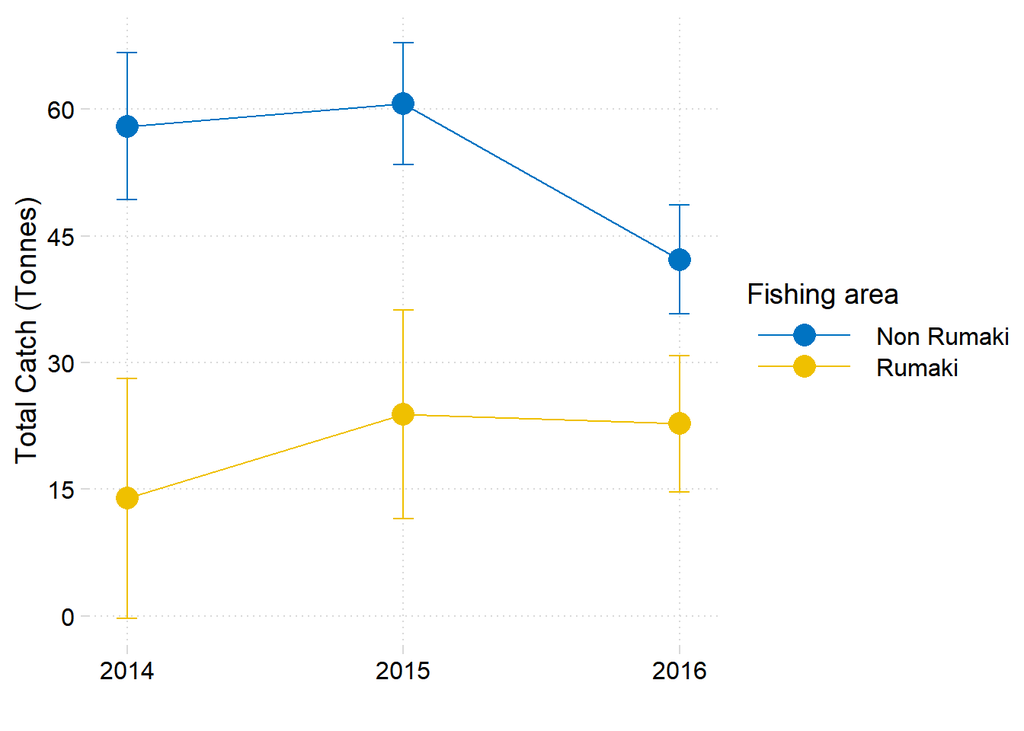

```r
catch.districts%>%
  filter(catch < 1000) %>%
  group_by(year, zone) %>%
  summarise(n = n(),
            mean.catch = median(catch, na.rm = TRUE),
            sd = sd(catch, na.rm = TRUE),
            se = sd/sqrt(n)) %>%
  ungroup() %>%
  ggplot(aes(x = year, y = mean.catch, col = zone)) +
  geom_line() +
  geom_point(size = 5)+
  geom_errorbar(aes(ymin = mean.catch-se, ymax = mean.catch+se), width = 0.075)+
  ggsci::scale_color_jco(name = "Fishing area", label = c("Non Rumaki", "Rumaki")) +
  scale_x_continuous(breaks = seq(2014,2016,1)) +
  scale_y_continuous(breaks = seq(0,95,15))+
  cowplot::theme_minimal_grid()+
  theme(panel.grid = element_line(linetype = "dotted"),
        legend.position = "right",
        legend.key.width = unit(2,"cm"))+
  labs(x = "", y = "Total Catch (Tonnes)")
```

```r
# catch.districts %>% filter(catch < 1000) %>% ggplot(aes(x = year, y = catch, col = zone)) + geom_point()
```

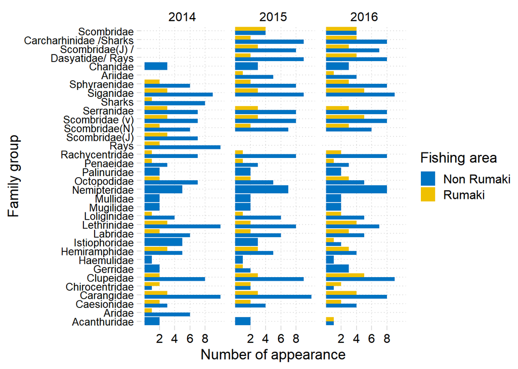

```r
catch.districts%>%
  filter(catch > 50) %>%
  group_by(family, zone, year)  %>%
  count() %>% ungroup() %>%
  filter(family != "Others") %>%
  # arrange((english.name)) %>%
  ggplot(aes(x = family, y = n, fill = zone)) +
  geom_col(position = "dodge")+
  coord_flip()+
  facet_wrap(~year)+
  cowplot::theme_minimal_grid()+
  theme(panel.grid = element_line(linetype = "dotted"))+
  ggsci::scale_fill_jco(name = "Fishing area", label = c("Non Rumaki", "Rumaki"))+
  scale_y_continuous(breaks = seq(2,9,2)) +
  labs(x = "Family group", y = "Number of appearance")+
  theme(axis.text.y = element_text(size = 10))
```

```r
catch.districts  %>%
  filter(english.name != "Others", catch > 300)  %>%
  group_by(english.name, zone, year)  %>%
  count() %>% ungroup() %>%
  pivot_wider(names_from = zone, values_from = n)%>%
  mutate(OTHER = replace(OTHER, !is.na(OTHER),"present"),
         OTHER = replace(OTHER, is.na(OTHER),"absent"),
         RUMAKI = replace(RUMAKI, !is.na(RUMAKI),"present"),
         RUMAKI = replace(RUMAKI, is.na(RUMAKI),"absent")) %>%
  pivot_longer(names_to = "zone", values_to = "present.absent", cols = 3:4, ) %>% filter(present.absent == "present") %>% group_by(zone, english.name,year) %>% tally()
```

```
## # A tibble: 41 x 4
## # Groups:   zone, english.name [22]
##    zone  english.name         year     n
##    <chr> <fct>               <int> <int>
##  1 OTHER Netuma thalassina    2015     1
##  2 OTHER Netuma thalassina    2016     1
##  3 OTHER Sardinella neglecta  2015     1
##  4 OTHER Sardinella neglecta  2016     1
##  5 OTHER Lethrinus harak      2015     1
##  6 OTHER Lethrinus harak      2016     1
##  7 OTHER Octopus chromatus    2015     1
##  8 OTHER Octopus chromatus    2016     1
##  9 OTHER Panulirus ornatus    2015     1
## 10 OTHER Panulirus ornatus    2016     1
## # ... with 31 more rows
```

```r
catch.districts  %>%
  filter(english.name != "Others", catch > 300)  %>%
  group_by(english.name, zone, year)  %>%
  count() %>% ungroup() %>%
  pivot_wider(names_from = zone, values_from = n)%>%
  mutate(OTHER = replace(OTHER, !is.na(OTHER),"present"),
         OTHER = replace(OTHER, is.na(OTHER),"absent"),
         RUMAKI = replace(RUMAKI, !is.na(RUMAKI),"present"),
         RUMAKI = replace(RUMAKI, is.na(RUMAKI),"absent")) %>%
  filter(OTHER == "absent" & RUMAKI == "present") %>% pivot_wider(names_from = year, values_from = 3:4) %>%
  kableExtra::kable(format = "html", caption = "Species found in Rumaki fishing area",
                    col.names = c("Species", "2015", "2016", "2015", "2016")) %>%
  kableExtra::add_header_above(c("", "Non Rumaki" = 2, "Rumaki" = 2)) %>%
  kableExtra::column_spec(column = 1:5, width = "5cm")
```

Species found in Rumaki fishing area

| Species | Non Rumaki 2015 | Non Rumaki 2016 | Rumaki 2015 | Rumaki 2016 |
| --- | --- | --- | --- | --- |
| Caesio xanthonota | absent | absent | present | present |
| Hemiramphus far | absent | absent | present | present |
| Xiphias gladius | absent | absent | present | present |

```r
catch.districts  %>%
  filter(english.name != "Others", catch > 300)  %>%
  group_by(english.name, zone, year)  %>%
  count() %>% ungroup() %>%
  pivot_wider(names_from = zone, values_from = n)%>%
  mutate(OTHER = replace(OTHER, !is.na(OTHER),"present"),
         OTHER = replace(OTHER, is.na(OTHER),"absent"),
         RUMAKI = replace(RUMAKI, !is.na(RUMAKI),"present"),
         RUMAKI = replace(RUMAKI, is.na(RUMAKI),"absent")) %>%
  filter(OTHER == "present" & RUMAKI == "absent") %>% pivot_wider(names_from = year, values_from = 3:4) %>%
  kableExtra::kable(format = "html", caption = "Species found in Non Rumaki fishing area",
                    col.names = c("Species", "2015", "2016", "2015", "2016")) %>%
  kableExtra::add_header_above(c("", "Non Rumaki" = 2, "Rumaki" = 2)) %>%
  kableExtra::column_spec(column = 1:5, width = "5cm")
```

Species found in Non Rumaki fishing area

| Species | Non Rumaki 2015 | Non Rumaki 2016 | Rumaki 2015 | Rumaki 2016 |
| --- | --- | --- | --- | --- |
| Netuma thalassina | present | present | absent | absent |
| Sardinella neglecta | NA | present | NA | absent |
| Panulirus ornatus | present | present | absent | absent |
| Rachycentron canadum | present | present | absent | absent |
| Cephalopholis argus | present | present | absent | absent |
| Sphyraena obtusata | present | present | absent | absent |

```r
catch.districts  %>%
  filter(english.name != "Others", catch > 300)  %>%
  group_by(english.name, zone, year)  %>%
  count() %>% ungroup() %>%
  pivot_wider(names_from = zone, values_from = n)%>%
  mutate(OTHER = replace(OTHER, !is.na(OTHER),"present"),
         OTHER = replace(OTHER, is.na(OTHER),"absent"),
         RUMAKI = replace(RUMAKI, !is.na(RUMAKI),"present"),
         RUMAKI = replace(RUMAKI, is.na(RUMAKI),"absent")) %>%
  filter(OTHER == "present" & RUMAKI == "present") %>% pivot_wider(names_from = year, values_from = 3:4)  %>%
  kableExtra::kable(format = "html", caption = "Species found in Rumaki and Non-Rumaki fishing areas",
                    col.names = c("Species", "2015", "2016", "2015", "2016")) %>%
  kableExtra::add_header_above(c("", "Non Rumaki" = 2, "Rumaki" = 2)) %>%
  kableExtra::column_spec(column = 1:5, width = "5cm")
```

Species found in Rumaki and Non-Rumaki fishing areas

| Species | Non Rumaki 2015 | Non Rumaki 2016 | Rumaki 2015 | Rumaki 2016 |
| --- | --- | --- | --- | --- |
| Sardinella neglecta | present | NA | present | NA |
| Lethrinus harak | present | present | present | present |
| Octopus chromatus | present | present | present | present |
| Penaeus Monodon | present | present | present | present |
| Pastinachus sephen | present | present | present | present |
| Rastrelliger kanagurta | present | present | present | present |
| Siganus Canaliculatus | present | NA | present | NA |

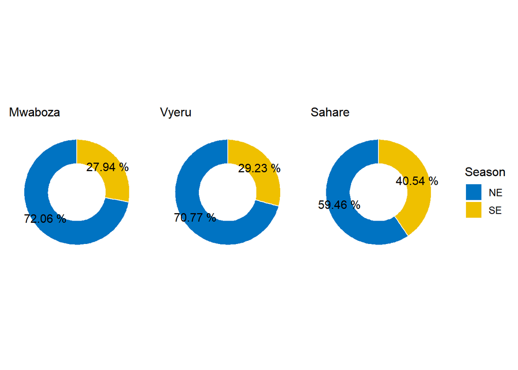

```r
phyto = readxl::read_excel("c:/Users/Semba/Desktop/working/Maggie/Manuscripts/phytoplankton_combined.xls", sheet = 1) %>% mutate(date = lubridate::dmy(Date)) %>% select(date, Date, Station, everything())

phyto.pa = phyto %>%
  dplyr::group_by(Station, Season, Diatoms) %>%
  tally() %>%
  ungroup() %>%
  pivot_wider(names_from = Station, values_from = n) %>%
  mutate(Mwaboza = replace(Mwaboza, !is.na(Mwaboza),"present"),
         Mwaboza = replace(Mwaboza, is.na(Mwaboza),"absent"),
         Sahare = replace(Sahare, !is.na(Sahare),"present"),
         Sahare = replace(Sahare, is.na(Sahare),"absent"),
         Vyeru = replace(Vyeru, !is.na(Vyeru),"present"),
         Vyeru = replace(Vyeru, is.na(Vyeru),"absent")) %>%
  pivot_longer(names_to = "sites", values_to = "present.absent", cols = 3:5) %>% filter(present.absent == "present") %>% group_by(sites, Season) %>% tally()


vyeru = phyto.pa%>%
  filter(sites == "Vyeru") %>%
  mutate(percentage = (n/sum(n) * 100) %>% round(2), labs = paste(percentage, "%")) %>%
  ggpubr::ggdonutchart(x = "percentage",
                       label = "labs",
                       fill = "Season", color = "white", lab.pos = "in")+
  ggsci::scale_fill_jco()+
  theme(legend.position = "none")+
  labs(subtitle = "Vyeru")

mwabo = phyto.pa%>%
  filter(sites == "Mwaboza") %>%
  mutate(percentage = (n/sum(n) * 100) %>% round(2), labs = paste(percentage, "%")) %>%
  ggpubr::ggdonutchart(x = "percentage",
                       label = "labs",
                       fill = "Season", color = "white", lab.pos = "in")+
  ggsci::scale_fill_jco()+
  theme(legend.position = "none")+
  labs(subtitle = "Mwaboza")

sahare = phyto.pa%>%
  filter(sites == "Sahare") %>%
  mutate(percentage = (n/sum(n) * 100) %>% round(2), labs = paste(percentage, "%")) %>%
  ggpubr::ggdonutchart(x = "percentage",
                       label = "labs",
                       fill = "Season", color = "white", lab.pos = "in")+
  ggsci::scale_fill_jco()+
  theme(legend.position = "right")+
  labs(subtitle = "Sahare")

egg::ggarrange(mwabo,vyeru,  sahare, nrow = 1)
```

```r
catch.districts %>% group_by(english.name, zone) %>% tally()%>% ungroup() %>%
  pivot_wider(names_from = zone, values_from = n)
```

```
## # A tibble: 34 x 3
##    english.name             OTHER RUMAKI
##    <fct>                    <int>  <int>
##  1 Naso hexacanthus            21     10
##  2 Netuma thalassina           21     10
##  3 Caesio xanthonota           21     10
##  4 carenx tille                21     10
##  5 Chanidae                    21     10
##  6 Chirocentrus nudus          20      9
##  7 Sardinella neglecta         21     10
##  8 Gerres oblongus             21     10
##  9 Pomadasys multimaculatum    21     10
## 10 Hemiramphus far             21     10
## # ... with 24 more rows
```

```r
catch.districts %>% group_by(english.name,zone) %>% count() %>% arrange(desc(n))
```

```
## # A tibble: 67 x 3
## # Groups:   english.name, zone [67]
##    english.name             zone       n
##    <fct>                    <fct>  <int>
##  1 <NA>                     OTHER    322
##  2 <NA>                     RUMAKI   138
##  3 Naso hexacanthus         OTHER     21
##  4 Netuma thalassina        OTHER     21
##  5 Caesio xanthonota        OTHER     21
##  6 carenx tille             OTHER     21
##  7 Chanidae                 OTHER     21
##  8 Sardinella neglecta      OTHER     21
##  9 Gerres oblongus          OTHER     21
## 10 Pomadasys multimaculatum OTHER     21
## # ... with 57 more rows
```